# Metabolites…Back to basics

Julin Maloof

02/22/2021

Take a different approach with metabolites:

1. ID metabolites responding to microbes
2. Ask if those are associated with leaf length

Here include genotype for the treatment models but use scaled and centered values for leaf associations.

NOTE: THIS IS THE FINAL ANALYSIS. TRIED AND DID NOT LIKE LME MODELS. TOO MANY SINGULARITIES. I THINK THERE IS NOT ENOUGH DATA TO ESTIMATE BLOCK EFFECCTS WELL.

NOTE: NEXT STEPS: TRY MAKING TERNARY PLOT WITH SIMPLE MEANS.

```r
library(tidyverse)
library(broom)
library(ggfortify)
```

get leaflength data

```r
leaflength <- read_csv("../../plant/output/leaf_lengths_metabolite.csv") %>%
  mutate(pot=str_pad(pot, width=3, pad="0"),
         sampleID=str_c("wyo", genotype, pot, sep="_")) %>%
  select(sampleID, genotype, trt, leaf_avg_std)
leaflength %>% arrange(sampleID)
```

| sampleID | genotype | trt | leaf_avg_std |
| --- | --- | --- | --- |
| wyo_FPsc_010 | FPsc | BLANK | -0.195176986 |
| wyo_FPsc_013 | FPsc | dead | -0.002831448 |
| wyo_FPsc_016 | FPsc | live | -1.724583154 |
| wyo_FPsc_115 | FPsc | live | 0.730509941 |
| wyo_FPsc_117 | FPsc | dead | -1.064715083 |
| wyo_FPsc_126 | FPsc | BLANK | -0.826970642 |
| wyo_FPsc_231 | FPsc | dead | -0.231217750 |
| wyo_FPsc_242 | FPsc | live | 1.083143428 |
| wyo_FPsc_250 | FPsc | BLANK | 0.381859629 |
| wyo_FPsc_326 | FPsc | dead | -0.785554914 |

[output cut: 26 more lines]

get and wrangle metabolite data

```r
met_raw <-read_csv("../input/metabolites_set1.csv")
met <- met_raw %>%
  mutate(pot=str_pad(pot, width = 3, pad = "0")) %>%
  mutate(sampleID=str_c("wyo", genotype, pot, sep="_")) %>%
  mutate(trt=ifelse(is.na(autoclave), "BLANK", autoclave)) %>%
  select(sampleID, genotype, tissue, trt, sample_mass = `sample_mass mg`, !submission_number:concatenate)  %>%

  #bring in leaf length
  left_join({leaflength %>% select(sampleID, leaf_avg_std)}) %>%
  select(sampleID, genotype, tissue, trt, leaf_avg_std, everything()) %>%

  #make long
  pivot_longer(!sampleID:sample_mass, names_to = "metabolite", values_to = "met_amt") %>%

  #filter away unnamed
  filter(str_detect(metabolite, pattern="^[0-9]+$", negate=TRUE)) %>%

  #adjust by sample mass
  mutate(met_per_mg=met_amt/sample_mass) %>%

  pivot_wider(id_cols = c(sampleID, genotype, trt, leaf_avg_std),
              names_from = c(tissue, metabolite),
              values_from = starts_with("met_"),
              names_sep = "_")
met
```

| sampleID | genotype | trt | leaf_avg_std | met_amt_leaf_xylulose NIST | met_amt_leaf_xylose | met_amt_leaf_xylonic acid isomer | met_amt_leaf_xylonic acid | met_amt_leaf_xanthine | met_amt_leaf_vanillic acid | met_amt_leaf_valine | met_amt_leaf_uridine | met_amt_leaf_urea | met_amt_leaf_uracil | met_amt_leaf_UDP-N-acetylglucosamine | met_amt_leaf_tyrosine | met_amt_leaf_tryptophan | met_amt_leaf_tocopherol alpha- | met_amt_leaf_thymine | met_amt_leaf_threonine | met_amt_leaf_threonic acid | met_amt_leaf_tagatose | met_amt_leaf_sucrose | met_amt_leaf_succinic acid | met_amt_leaf_stigmasterol | met_amt_leaf_stearic acid | met_amt_leaf_spermidine | met_amt_leaf_sinapinic acid | met_amt_leaf_shikimic acid | met_amt_leaf_serine | … |
| --- | --- | --- | --- | --- | --- | --- | --- | --- | --- | --- | --- | --- | --- | --- | --- | --- | --- | --- | --- | --- | --- | --- | --- | --- | --- | --- | --- | --- | --- | --- |
| wyo_R500_038 | R500 | dead | -0.665154457 | 21849 | 26654 | 2895 | 2707 | 649 | 749 | 134843 | 2589 | 23094 | 9084 | 531 | 53897 | 8835 | 2035 | 595 | 15901 | 28158 | 2549 | 5426 | 17706 | 442 | 307145 | 373 | 970 | 12369 | 60862 | … |
| wyo_FPsc_115 | FPsc | live | 0.730509941 | 43247 | 28582 | 5252 | 3067 | 203 | 452 | 160633 | 5438 | 4836 | 12047 | 210 | 89058 | 16278 | 1382 | 279 | 32031 | 15773 | 2549 | 2051 | 36788 | 134 | 128071 | 192 | 8338 | 22206 | 703405 | … |
| wyo_FPsc_117 | FPsc | dead | -1.064715083 | 21512 | 21483 | 5131 | 2243 | 235 | 237 | 491968 | 6103 | 10170 | 9460 | 229 | 123625 | 28524 | 1851 | 227 | 61281 | 14752 | 1527 | 2062 | 33333 | 240 | 165812 | 1197 | 6466 | 19890 | 244018 | … |
| wyo_R500_120 | R500 | dead | -0.524929452 | 39403 | 58608 | 5903 | 4791 | 215 | 384 | 138063 | 1409 | 8848 | 3388 | 261 | 84237 | 28700 | 1367 | 217 | 35279 | 38490 | 2649 | 4121 | 33026 | 229 | 132221 | 717 | 2184 | 25351 | 240271 | … |
| wyo_R500_130 | R500 | live | 0.204240571 | 51546 | 45476 | 4596 | 4265 | 156 | 299 | 166351 | 1503 | 9013 | 2631 | 287 | 59700 | 15531 | 2627 | 102 | 33333 | 58245 | 4257 | 11314 | 15038 | 263 | 195187 | 340 | 2195 | 6855 | 94808 | … |
| wyo_FPsc_231 | FPsc | dead | -0.231217750 | 14680 | 27776 | 6223 | 2577 | 227 | 752 | 373980 | 3948 | 11074 | 3671 | 263 | 52805 | 7275 | 1526 | 414 | 52532 | 10926 | 2458 | 6060 | 38024 | 420 | 241766 | 378 | 8604 | 18191 | 166777 | … |
| wyo_R500_238 | R500 | dead | 0.897178796 | 29247 | 32933 | 4921 | 3187 | 307 | 1012 | 83518 | 2413 | 13058 | 3612 | 455 | 20328 | 3815 | 4013 | 363 | 12045 | 21202 | 3310 | 63527 | 14734 | 527 | 391560 | 503 | 9431 | 6689 | 37235 | … |
| wyo_FPsc_242 | FPsc | live | 1.083143428 | 36305 | 37434 | 7697 | 3933 | 276 | 194 | 141840 | 1758 | 8119 | 3882 | 239 | 44438 | 12304 | 1807 | 184 | 25678 | 18712 | 3551 | 8263 | 44170 | 158 | 183007 | 384 | 11022 | 13733 | 259205 | … |
| wyo_R500_005 | R500 | live | -1.254099476 | 32234 | 33333 | 3560 | 3484 | 193 | 533 | 225373 | 1343 | 5465 | 7830 | 253 | 121588 | 31459 | 1123 | 240 | 38033 | 27632 | 3159 | 2030 | 25657 | 214 | 133960 | 351 | 618 | 9385 | 167771 | … |
| wyo_R500_254 | R500 | live | 1.217345211 | 22941 | 34127 | 3067 | 5152 | 164 | 313 | 89226 | 815 | 5907 | 2388 | 460 | 37406 | 6060 | 1601 | 149 | 19182 | 27848 | 2665 | 497808 | 28373 | 227 | 123534 | 464 | 7666 | 14692 | 161593 | … |

[output cut: 26 more lines]

PC analysis

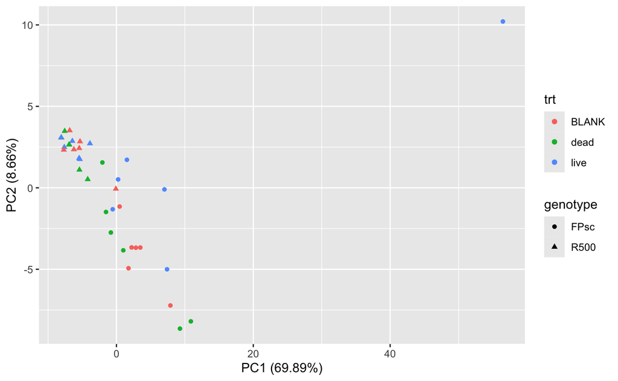

```r
met.pc.root <- met %>% select(starts_with("met_per_mg_root")) %>%
  prcomp(scale. = TRUE)
autoplot(met.pc.root, data=met, color = "trt", shape = "genotype", scale = 0 )
```

```r
which.max(met.pc.root$x[,"PC1"])
```

```
[1] 24
```

```r
which.max(met.pc.root$x[,"PC2"])
```

```
[1] 24
```

```r
met.pc.root$x[24,1:2]
```

```
     PC1      PC2
56.47944 10.20945
```

```r
root.outlier <- met$sampleID[which.max(met.pc.root$x[,"PC1"])]
```

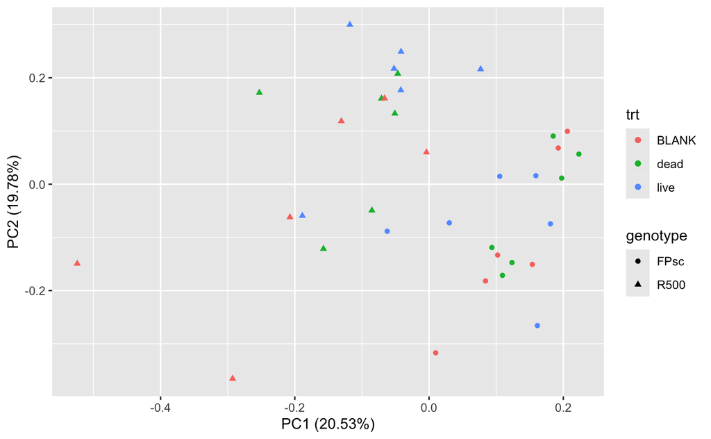

```r
met.pc.leaf <- met %>% select(starts_with("met_per_mg_leaf")) %>%
  prcomp(scale. = TRUE)
autoplot(met.pc.leaf, data=met, color = "trt", shape = "genotype" )
```

leafs look okay

```r
root.outlier
```

```
[1] "wyo_FPsc_016"
```

recalcualte root PCs

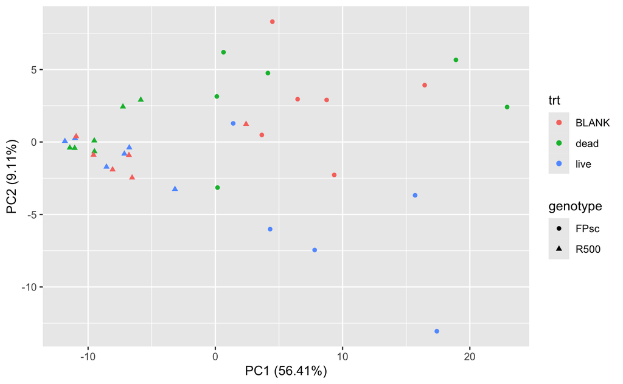

```r
met.pc.root <- met.censor  %>% select(starts_with("met_per_mg_root")) %>%
  na.omit() %>%
  prcomp(scale. = TRUE)
autoplot(met.pc.root, data=na.omit(met.censor), color = "trt", shape = "genotype", scale = 0 )
```

split this into two data frames, one normalized by tissue amount and one not.

```r
met_per_mg <- met.censor %>% select(sampleID, genotype, trt, leaf_avg_std, starts_with("met_per_mg")) %>%
  as.data.frame() %>% column_to_rownames("sampleID")
met_amt <- met.censor %>% select(sampleID,  genotype, trt, leaf_avg_std, starts_with("met_amt")) %>%
  as.data.frame() %>% column_to_rownames("sampleID")
```

## find sig metabolites

Live vs blank dead

normalized

```r
met_per_mg_lm <- met_per_mg %>%
  mutate(trt=ifelse(str_detect(trt, "live"), "live", "blank_dead")) %>%
  pivot_longer(cols=starts_with("met"), names_to = "metabolite") %>%
  mutate(tissue=str_extract(metabolite, "leaf|root")) %>%
  na.omit() %>%

  #scale and center
  group_by(metabolite, genotype, tissue) %>%
  mutate(value_scale=scale(value)) %>%

  # fit an lm for each metabolite response to trt
  # and a separate lm for each metabolite association with leaf length
  group_by(metabolite) %>%
  nest() %>%
  mutate(lm_trt=map(data, ~ lm(value~ trt*genotype   , data=.)),
         lm_leaf=map(data, ~ lm(leaf_avg_std ~ value_scale, data=.)))
```

```r
# summarize the lm results

## response to treatment results
met_per_mg_lm_results_trt <- met_per_mg_lm %>% mutate(broomtidy.trt = map(lm_trt, broom::tidy)) %>%
  unnest(broomtidy.trt) %>%
  select(metabolite, term, estimate, p.value) %>%
  pivot_wider(id_cols = metabolite, names_from = term, values_from = c(estimate, p.value), names_prefix = "trt_") %>%
  select(-`p.value_trt_(Intercept)`)

## association with leaf length results
met_per_mg_lm_results_leaf <- met_per_mg_lm %>% mutate(broomtidy.leaf = map(lm_leaf, broom::tidy)) %>%
  unnest(broomtidy.leaf) %>%
  select(metabolite, term, estimate, p.value) %>%
  pivot_wider(id_cols = metabolite, names_from = term, values_from = c(estimate, p.value), names_prefix = "leaf_") %>%
  select(-`p.value_leaf_(Intercept)`)

## combine trt and leaf length results
met_per_mg_lm_results <- inner_join(met_per_mg_lm_results_trt, met_per_mg_lm_results_leaf) %>%
  mutate(tissue=str_extract(metabolite,"(leaf|root)")) %>%
  group_by(tissue) %>%
  mutate(across(starts_with("p.value"), .fns = p.adjust, method = "fdr", .names = "FDR_{.col}")) %>%
  rename_with(~ str_replace(.x, "FDR_p.value", "FDR")) %>%
  ungroup()
```

FDR summary

```r
met_per_mg_lm_results %>%
  mutate(both=(FDR_trt_trtlive < 0.1) & (FDR_leaf_value_scale < 0.1)) %>%
  group_by(tissue) %>%
  summarize(across(starts_with("FDR"), ~ sum(.x < .1)), both=sum(both), count=n())
```

| tissue | FDR_trt_trtlive | FDR_trt_genotypeR500 | FDR_trt_trtlive:genotypeR500 | FDR_leaf_value_scale | both | count |
| --- | --- | --- | --- | --- | --- | --- |
| leaf | 0 | 71 | 0 | 0 | 0 | 176 |
| root | 40 | 150 | 0 | 0 | 0 | 176 |

p.value summary

```r
met_per_mg_lm_results %>%
  mutate(both=(p.value_trt_trtlive < 0.1) & (p.value_leaf_value_scale < 0.1)) %>%
  group_by(tissue) %>%
  summarize(across(starts_with("p.value"), ~ sum(.x < .05)), both=sum(both), count=n())
```

| tissue | p.value_trt_trtlive | p.value_trt_genotypeR500 | p.value_trt_trtlive:genotypeR500 | p.value_leaf_value_scale | both | count |
| --- | --- | --- | --- | --- | --- | --- |
| leaf | 9 | 73 | 8 | 31 | 6 | 176 |
| root | 52 | 144 | 21 | 8 | 11 | 176 |

Any FDR for both?

```r
met_per_mg_lm_results %>% filter(FDR_trt_trtlive < 0.1 & FDR_leaf_value_scale < 0.1) %>%
  select(metabolite, FDR_trt_trtlive, FDR_leaf_value_scale)
```

| metabolite | FDR_trt_trtlive | FDR_leaf_value_scale |
| --- | --- | --- |

Metabolites passing p.value for both

```r
met_per_mg_lm_results %>% filter(p.value_trt_trtlive < 0.05 & p.value_leaf_value_scale < 0.05) %>%
  select(metabolite, p.value_trt_trtlive, p.value_leaf_value_scale, FDR_trt_trtlive, FDR_leaf_value_scale) %>%
  arrange(p.value_leaf_value_scale)
```

| metabolite | p.value_trt_trtlive | p.value_leaf_value_scale | FDR_trt_trtlive | FDR_leaf_value_scale |
| --- | --- | --- | --- | --- |
| met_per_mg_root_galactinol | 0.022166751 | 0.004821529 | 0.09873688 | 0.4722636 |
| met_per_mg_root_dehydroascorbic acid | 0.003147580 | 0.008464641 | 0.03956958 | 0.4722636 |
| met_per_mg_root_fructose-6-phosphate | 0.007886858 | 0.009580586 | 0.05338796 | 0.4722636 |
| met_per_mg_root_cyano-l-alanine | 0.005914258 | 0.010733264 | 0.04525693 | 0.4722636 |
| met_per_mg_root_cyanoalanine | 0.001033642 | 0.014720159 | 0.01819210 | 0.5181496 |
| met_per_mg_root_glucose-6-phosphate | 0.003686403 | 0.017988937 | 0.04055044 | 0.5276755 |
| met_per_mg_root_shikimic acid | 0.003498098 | 0.035696952 | 0.04055044 | 0.7853329 |

write the results (Table S10)

```r
met_per_mg_lm_results %>%
  #filter(FDR.trt < 0.1 | FDR.leaf < 0.1) %>%
  mutate(sig.both = FDR_trt_trtlive < 0.1 & FDR_leaf_value_scale < 0.1) %>%
  mutate(metabolite=str_remove(metabolite, "met_.*(leaf|root)_")) %>%
  select(metabolite, tissue, everything()) %>%
  arrange(desc(sig.both), min(.$FDR_trt_trtlive, .$FDR_leaf_value_scale)) %>%
  write_csv("../output/met_per_mg_lm_full.csv")
```

Table S12

```r
met_per_mg_lm_results %>% filter(FDR_trt_trtlive < 0.1 | FDR_leaf_value_scale < 0.1) %>%
  select(metabolite, tissue, estimate_trt_trtlive, estimate_leaf_value_scale, p.value_trt_trtlive, p.value_leaf_value_scale, FDR_trt_trtlive, FDR_leaf_value_scale) %>%
  mutate(metabolite=str_remove(metabolite, "met_.*(leaf|root)_")) %>%
  arrange(tissue, p.value_leaf_value_scale) %>%
  write_csv("../output/met_per_mg_lm_full_filter.csv")
```

## raw

```r
met_amt_lm <- met_amt %>%
  mutate(trt=ifelse(str_detect(trt, "live"), "live", "blank_dead")) %>%
  pivot_longer(cols=starts_with("met"), names_to = "metabolite") %>%
  mutate(tissue=str_extract(metabolite, "leaf|root")) %>%
  na.omit() %>%

  #scale and center
  group_by(metabolite, genotype, tissue) %>%
  mutate(value_scale=scale(value)) %>%

  #fit lm for treatment effects and separately for leaf length association
  group_by(metabolite) %>%
  nest() %>%
  mutate(lm_trt=map(data, ~ lm(value ~ trt * genotype, data=.)),
         lm_leaf=map(data, ~ lm(leaf_avg_std ~ value_scale, data=.)))
```

Summarize the results

```r
#treatment results
met_amt_lm_results_trt <- met_amt_lm %>% mutate(broomtidy.trt = map(lm_trt, broom::tidy)) %>%
  unnest(broomtidy.trt) %>%
  select(metabolite, term, estimate, p.value) %>%
  pivot_wider(id_cols = metabolite, names_from = term, values_from = c(estimate, p.value), names_prefix = "trt_") %>%
  select(-`p.value_trt_(Intercept)`)

#leaf length results
met_amt_lm_results_leaf <- met_amt_lm %>% mutate(broomtidy.leaf = map(lm_leaf, broom::tidy)) %>%
  unnest(broomtidy.leaf) %>%
  select(metabolite, term, estimate, p.value) %>%
  pivot_wider(id_cols = metabolite, names_from = term, values_from = c(estimate, p.value), names_prefix = "leaf_") %>%
  select(-`p.value_leaf_(Intercept)`)

#combine and calcualte FDR
met_amt_lm_results <- inner_join(met_amt_lm_results_trt, met_amt_lm_results_leaf) %>%
  mutate(tissue=str_extract(metabolite,"(leaf|root)")) %>%
  group_by(tissue) %>%
  mutate(across(starts_with("p.value"), .fns = p.adjust, method = "fdr", .names = "FDR_{.col}")) %>%
  rename_with(~ str_replace(.x, "FDR_p.value", "FDR")) %>%
  ungroup()
```

Summarize by FDR

```r
met_amt_lm_results %>%
  mutate(both=(FDR_trt_trtlive < 0.1) & (FDR_leaf_value_scale < 0.1)) %>%
  group_by(tissue) %>%
  summarize(across(starts_with("FDR"), ~ sum(.x < .1)), both=sum(both), count=n())
```

| tissue | FDR_trt_trtlive | FDR_trt_genotypeR500 | FDR_trt_trtlive:genotypeR500 | FDR_leaf_value_scale | both | count |
| --- | --- | --- | --- | --- | --- | --- |
| leaf | 0 | 87 | 0 | 9 | 0 | 176 |
| root | 22 | 52 | 0 | 5 | 3 | 176 |

Summarize by p.value

```r
met_amt_lm_results %>%
  mutate(both=(p.value_trt_trtlive < 0.1) & (p.value_leaf_value_scale < 0.1)) %>%
  group_by(tissue) %>%
  summarize(across(starts_with("p.value"), ~ sum(.x < .05)), both=sum(both), count=n())
```

| tissue | p.value_trt_trtlive | p.value_trt_genotypeR500 | p.value_trt_trtlive:genotypeR500 | p.value_leaf_value_scale | both | count |
| --- | --- | --- | --- | --- | --- | --- |
| leaf | 8 | 87 | 3 | 41 | 10 | 176 |
| root | 36 | 65 | 17 | 22 | 13 | 176 |

Any metabolites significant for both by FDR?

```r
met_amt_lm_results %>% filter(FDR_trt_trtlive < 0.1 & FDR_leaf_value_scale < 0.1) %>%
  select(metabolite, FDR_trt_trtlive, FDR_leaf_value_scale)
```

| metabolite | FDR_trt_trtlive | FDR_leaf_value_scale |
| --- | --- | --- |
| met_amt_root_pseudo uridine | 0.08725717 | 0.01172842 |
| met_amt_root_cyano-l-alanine | 0.03012084 | 0.09357486 |
| met_amt_root_cyanoalanine | 0.01579730 | 0.09357486 |

Any metabolites significant for both by p.value??

```r
met_amt_lm_results %>% filter(p.value_trt_trtlive < 0.1 & p.value_leaf_value_scale < 0.1) %>%
  select(metabolite, p.value_trt_trtlive, p.value_leaf_value_scale, FDR_trt_trtlive, FDR_leaf_value_scale) %>%
  arrange(p.value_leaf_value_scale)
```

| metabolite | p.value_trt_trtlive | p.value_leaf_value_scale | FDR_trt_trtlive | FDR_leaf_value_scale |
| --- | --- | --- | --- | --- |
| met_amt_root_pseudo uridine | 0.0104113670 | 6.663873e-05 | 0.08725717 | 0.01172842 |
| met_amt_root_cyano-l-alanine | 0.0022248351 | 1.271409e-03 | 0.03012084 | 0.09357486 |
| met_amt_leaf_valine | 0.0744658614 | 1.367729e-03 | 0.77744282 | 0.07322161 |
| met_amt_root_cyanoalanine | 0.0005552205 | 2.417664e-03 | 0.01579730 | 0.09357486 |
| met_amt_root_shikimic acid | 0.0707776079 | 2.658377e-03 | 0.27080128 | 0.09357486 |
| met_amt_leaf_isoleucine | 0.0787830963 | 3.313128e-03 | 0.77744282 | 0.07322161 |
| met_amt_leaf_alanine | 0.0284486571 | 2.104745e-02 | 0.77744282 | 0.16105875 |
| met_amt_root_putrescine | 0.0212313945 | 2.783743e-02 | 0.14946902 | 0.36072307 |
| met_amt_leaf_citric acid | 0.0867163248 | 3.043135e-02 | 0.77744282 | 0.17617878 |
| met_amt_root_melezitose | 0.0750537945 | 3.253279e-02 | 0.28029415 | 0.36072307 |

[output cut: 13 more lines]

Write it out (Table S9)

```r
met_amt_lm_results %>%
  #filter(FDR.trt < 0.1 | FDR.leaf < 0.1) %>%
  mutate(sig.both = FDR_trt_trtlive < 0.1 & FDR_leaf_value_scale < 0.1) %>%
  mutate(metabolite=str_remove(metabolite, "met_.*(leaf|root)_")) %>%
  arrange(desc(sig.both), min(.$FDR_trt_trtlive, .$FDR_leaf_value_scale)) %>%
  select(metabolite, tissue, everything()) %>%
  write_csv("../output/met_amt_lm_full.csv")
```

Table S11

```r
met_amt_lm_results %>% filter(FDR_trt_trtlive < 0.1 | FDR_leaf_value_scale < 0.1) %>%
  select(metabolite, tissue, estimate_trt_trtlive, estimate_leaf_value_scale, p.value_trt_trtlive, p.value_leaf_value_scale, FDR_trt_trtlive, FDR_leaf_value_scale) %>%
    mutate(metabolite=str_remove(metabolite, "met_.*(leaf|root)_")) %>%
  arrange(tissue, p.value_leaf_value_scale) %>%
  write_csv("../output/met_amt_lm_full_filtered.csv")
```

# NO BLANK

## find sig metabolites

Live vs dead

normalized

```r
met_per_mg_lm <- met_per_mg %>%
  filter(trt != "BLANK") %>%
  mutate(trt=ifelse(str_detect(trt, "live"), "live", "blank_dead")) %>%
  pivot_longer(cols=starts_with("met"), names_to = "metabolite") %>%
  mutate(tissue=str_extract(metabolite, "leaf|root")) %>%

  #scale and center
  group_by(metabolite, genotype, tissue) %>%
  mutate(value_scale=scale(value)) %>%
  group_by(metabolite) %>%
  nest() %>%
  mutate(lm_trt=map(data, ~ lm(value ~ trt * genotype, data=.)),
         lm_leaf=map(data, ~ lm(leaf_avg_std ~ value_scale, data=.)))
```

```r
met_per_mg_lm_results_trt <- met_per_mg_lm %>% mutate(broomtidy.trt = map(lm_trt, broom::tidy)) %>%
  unnest(broomtidy.trt) %>%
  select(metabolite, term, estimate, p.value) %>%
  pivot_wider(id_cols = metabolite, names_from = term, values_from = c(estimate, p.value), names_prefix = "trt_") %>%
  select(-`p.value_trt_(Intercept)`)

met_per_mg_lm_results_leaf <- met_per_mg_lm %>% mutate(broomtidy.leaf = map(lm_leaf, broom::tidy)) %>%
  unnest(broomtidy.leaf) %>%
  select(metabolite, term, estimate, p.value) %>%
  pivot_wider(id_cols = metabolite, names_from = term, values_from = c(estimate, p.value), names_prefix = "leaf_") %>%
  select(-`p.value_leaf_(Intercept)`)

met_per_mg_lm_results <- inner_join(met_per_mg_lm_results_trt, met_per_mg_lm_results_leaf) %>%
  mutate(tissue=str_extract(metabolite,"(leaf|root)")) %>%
  group_by(tissue) %>%
  mutate(across(starts_with("p.value"), .fns = p.adjust, method = "fdr", .names = "FDR_{.col}")) %>%
  rename_with(~ str_replace(.x, "FDR_p.value", "FDR")) %>%
  ungroup()
met_per_mg_lm_results %>%
  mutate(both=(FDR_trt_trtlive < 0.1) & (FDR_leaf_value_scale < 0.1)) %>%
  group_by(tissue) %>%
  summarize(across(starts_with("FDR"), ~ sum(.x < .1)), both=sum(both), count=n())
```

| tissue | FDR_trt_trtlive | FDR_trt_genotypeR500 | FDR_trt_trtlive:genotypeR500 | FDR_leaf_value_scale | both | count |
| --- | --- | --- | --- | --- | --- | --- |
| leaf | 0 | 50 | 1 | 4 | 0 | 176 |
| root | 13 | 138 | 1 | 0 | 0 | 176 |

```r
met_per_mg_lm_results %>% filter(FDR_trt_trtlive < 0.1 & FDR_leaf_value_scale < 0.1) %>%
  select(metabolite, FDR_trt_trtlive, FDR_leaf_value_scale)
```

| metabolite | FDR_trt_trtlive | FDR_leaf_value_scale |
| --- | --- | --- |

```r
met_per_mg_lm_results %>%
  #filter(FDR.trt < 0.1 | FDR.leaf < 0.1) %>%
  mutate(sig.both = FDR_trt_trtlive < 0.1 & FDR_leaf_value_scale < 0.1) %>%
  arrange(desc(sig.both), min(.$FDR_trt_trtlive, .$FDR_leaf_value_scale)) %>%
  write_csv("../output/met_per_mg_lm_full_NOBLANK.csv")
```

raw

```r
met_amt_lm <- met_amt %>%
  filter(trt != "BLANK") %>%
  pivot_longer(cols=starts_with("met"), names_to = "metabolite") %>%
  mutate(tissue=str_extract(metabolite, "leaf|root")) %>%

  #scale and center
  group_by(metabolite, genotype, tissue) %>%
  mutate(value_scale=scale(value)) %>%
  group_by(metabolite) %>%
  nest() %>%
  mutate(lm_trt=map(data, ~ lm(value ~ trt * genotype, data=.)),
         lm_leaf=map(data, ~ lm(leaf_avg_std ~ value_scale, data=.)))
```

```r
met_amt_lm_results_trt <- met_amt_lm %>% mutate(broomtidy.trt = map(lm_trt, broom::tidy)) %>%
  unnest(broomtidy.trt) %>%
  select(metabolite, term, estimate, p.value) %>%
  pivot_wider(id_cols = metabolite, names_from = term, values_from = c(estimate, p.value), names_prefix = "trt_") %>%
  select(-`p.value_trt_(Intercept)`)

met_amt_lm_results_leaf <- met_amt_lm %>% mutate(broomtidy.leaf = map(lm_leaf, broom::tidy)) %>%
  unnest(broomtidy.leaf) %>%
  select(metabolite, term, estimate, p.value) %>%
  pivot_wider(id_cols = metabolite, names_from = term, values_from = c(estimate, p.value), names_prefix = "leaf_") %>%
  select(-`p.value_leaf_(Intercept)`)

met_amt_lm_results <- inner_join(met_amt_lm_results_trt, met_amt_lm_results_leaf) %>%
  mutate(tissue=str_extract(metabolite,"(leaf|root)")) %>%
  group_by(tissue) %>%
  mutate(across(starts_with("p.value"), .fns = p.adjust, method = "fdr", .names = "FDR_{.col}")) %>%
  rename_with(~ str_replace(.x, "FDR_p.value", "FDR")) %>%
  ungroup()
met_amt_lm_results %>%
  mutate(both=(FDR_trt_trtlive < 0.1) & (FDR_leaf_value_scale < 0.1)) %>%
  group_by(tissue) %>%
  summarize(across(starts_with("FDR"), ~ sum(.x < .1)), both=sum(both), count=n())
```

| tissue | FDR_trt_trtlive | FDR_trt_genotypeR500 | FDR_trt_trtlive:genotypeR500 | FDR_leaf_value_scale | both | count |
| --- | --- | --- | --- | --- | --- | --- |
| leaf | 0 | 65 | 0 | 3 | 0 | 176 |
| root | 20 | 38 | 1 | 0 | 0 | 176 |

```r
met_amt_lm_results %>% filter(FDR_trt_trtlive < 0.1 & FDR_leaf_value_scale < 0.1) %>%
  select(metabolite, FDR_trt_trtlive, FDR_leaf_value_scale)
```

| metabolite | FDR_trt_trtlive | FDR_leaf_value_scale |
| --- | --- | --- |

```r
met_amt_lm_results %>%
  #filter(FDR.trt < 0.1 | FDR.leaf < 0.1) %>%
  mutate(sig.both = FDR_trt_trtlive < 0.1 & FDR_leaf_value_scale < 0.1) %>%
  arrange(desc(sig.both), min(.$FDR_trt_trtlive, .$FDR_leaf_value_scale)) %>%
  write_csv("../output/met_amt_lm_full_NOBLANK.csv")
```